# HOMEWORK 1

## READING THE DATA

```r
library(data.table)
library(dplyr)
library(tidyr)
```

```r
DTbetsData <- fread(file="c:/Users/BAHADIR/Desktop/IE 582/HW 1/rCode/bets.csv", header=TRUE, sep="," , stringsAsFactors=TRUE)
DTbookingData <- fread(file="c:/Users/BAHADIR/Desktop/IE 582/HW 1/rCode/booking.csv", header=TRUE, sep=",",stringsAsFactors=TRUE)
DTgoalsData <- fread(file="c:/Users/BAHADIR/Desktop/IE 582/HW 1/rCode/goals.csv", header=TRUE, sep=",",stringsAsFactors=TRUE)
DTmatchesData <- fread(file="c:/Users/BAHADIR/Desktop/IE 582/HW 1/rCode/matches.csv", header=TRUE, sep=",",stringsAsFactors=TRUE)
DTstatsData <- fread(file="c:/Users/BAHADIR/Desktop/IE 582/HW 1/rCode/stats.csv", header=TRUE, sep=",",stringsAsFactors=TRUE)

setnames(DTmatchesData,"match_hometeam_score","goal_1")
setnames(DTmatchesData,"match_awayteam_score","goal_2")

DTgoalsData<-separate(DTgoalsData,score,c("goal_1","goal_2")," - ",convert=TRUE)
DTpremierMatches<- DTmatchesData[match_status=="Finished" & league_id == 148]

premierMatchIds <- DTpremierMatches$match_id
premierScore<-DTpremierMatches
```

## TASK 1

As expected, first two distributions are looking like poisson distribution. The last one is similar to normal distribution, although looks like a little bit skewed to the home team side.

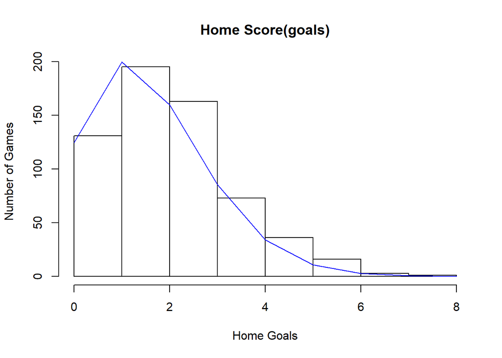

```r
hist(premierScore$goal_1,main = "Home Score(goals)", xlab= "Home Goals", ylab = "Number of Games" , right = FALSE)
q2ax<-0:8
q2ay <-dpois(x=q2ax,lambda=mean(premierScore$goal_1))*NROW(premierScore)
lines(q2ax,q2ay,col="blue")
```

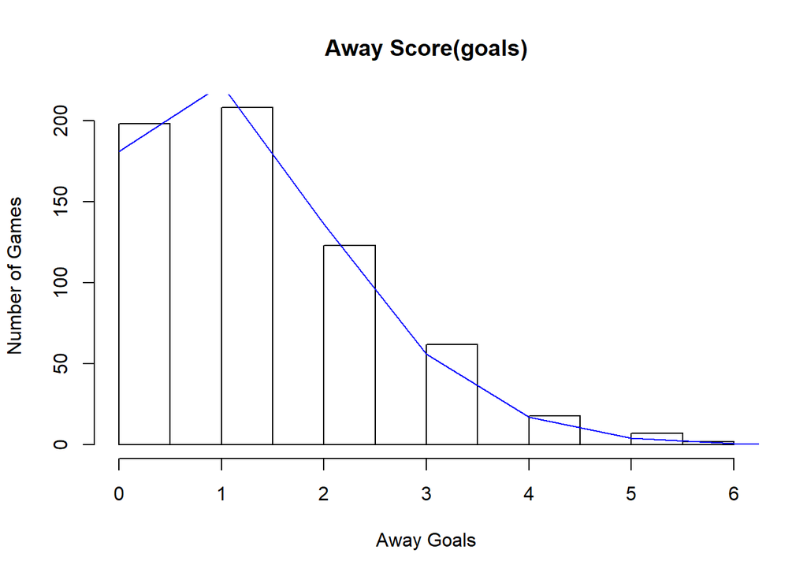

```r
hist(premierScore$goal_2,main = "Away Score(goals)", xlab= "Away Goals", ylab = "Number of Games", right = FALSE)
q2ay <-dpois(x=q2ax,lambda=mean(premierScore$goal_2))*NROW(premierScore)
lines(q2ax,q2ay,col="blue")
```

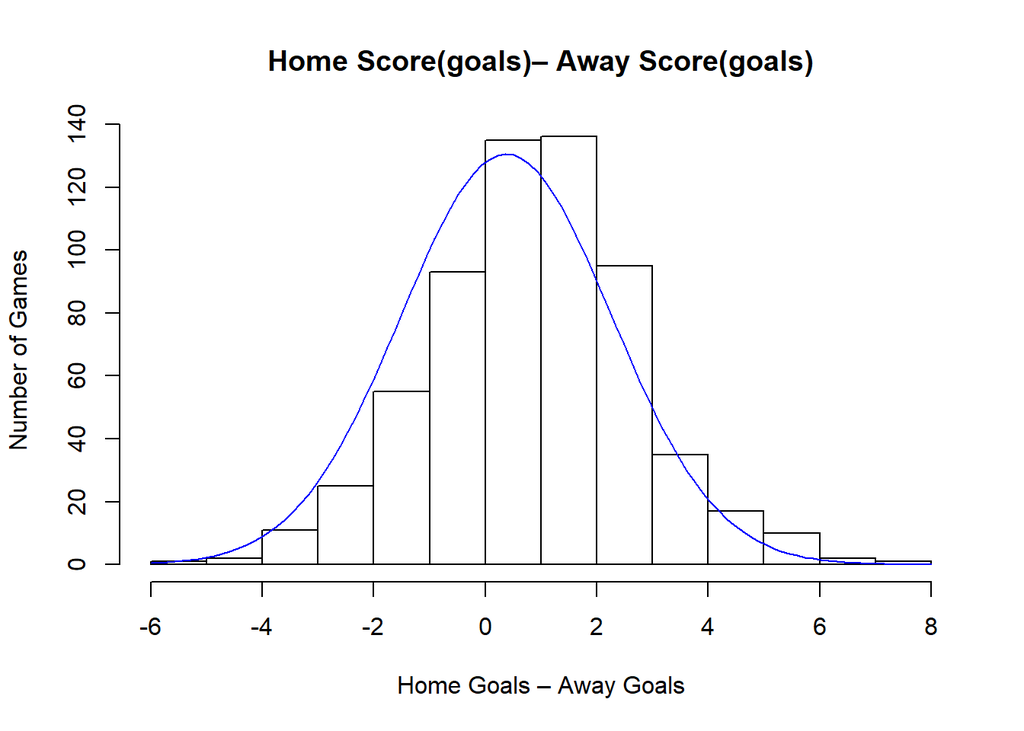

```r
hist(premierScore$goal_1-premierScore$goal_2,main = "Home Score(goals)– Away Score(goals)", xlab= "Home Goals – Away Goals", ylab = "Number of Games", right = FALSE)
q2axx<-seq(min(premierScore$goal_1-premierScore$goal_2),max(premierScore$goal_1-premierScore$goal_2),length.out = 100)
q2ay <-dnorm(x=q2axx,mean(premierScore$goal_1-premierScore$goal_2),sd(premierScore$goal_1-premierScore$goal_2))*NROW(premierScore)
lines(q2axx,q2ay,col="blue")
```

## TASK 2

I selected 10Bet, Unibet, bwin, and 1xBet bookmakers for this part since those ones had the highest number of observations.

```r
selectedBookmakers <- c("10Bet","Unibet","bwin","1xBet")
premierBets<-DTbetsData[odd_bookmakers%in%selectedBookmakers&variable%in%c("odd_1","odd_x","odd_2")&match_id%in%premierMatchIds]
setkey(premierBets,odd_epoch,odd_bookmakers)
```

Used tidyer package to spread the table and calculate necessary probabilities and normalized probabilities.

```r
premierBets <- premierBets %>% spread(variable, value)

premierBets[,c("Podd_1", "Podd_2","Podd_x"):=list((1/odd_1),(1/odd_2),(1/odd_x)),]
premierBets[,c("Psum"):=(Podd_1 + Podd_2 + Podd_x),]
premierBets[,c("Pnorm1", "Pnorm2","PnormX"):=list(Podd_1/Psum,Podd_2/Psum,Podd_x/Psum),]
premierBets[,"Pdiff":=Podd_1-Podd_2,]
```

I set each bin to be size of 0.04, I ignored high implied probabilities by drawing the graphs by up to 0.5 probability.

```r
bins<-seq(-1,1,by=0.04)
DTpremierMatches[,"result" := ifelse(goal_1>goal_2,1,ifelse(goal_2>goal_1,2,0))]
```

Used cut function in order to seperate data into bins based on Pdiff values. Then inner joined with matches data in order to calculate actual results. Matches data contains already finished games in Premier League at this point.

```r
binCounts <- cut(premierBets$Pdiff, bins, include.lowest = TRUE)
premierBets[,"bins":= binCounts]
setkey(premierBets,match_id)
setkey(DTpremierMatches,match_id)
joinTable <- premierBets[DTpremierMatches, nomatch=0]
joinTable <- joinTable[,.(match_id,odd_bookmakers,result,Pdiff,bins)]
```

Below the number of games are counted in terms of draw results, and implied probabilities are calculated.

```r
joinTable <-joinTable[,c("total","actual" ,"prob") := list(.N, sum(result==0),(sum(result==0)/.N)),by = bins]
```

Below are the single plot for each bookmaker and one for all 4 bookmakers. Implied probabilities calculated from data are shown in blue.

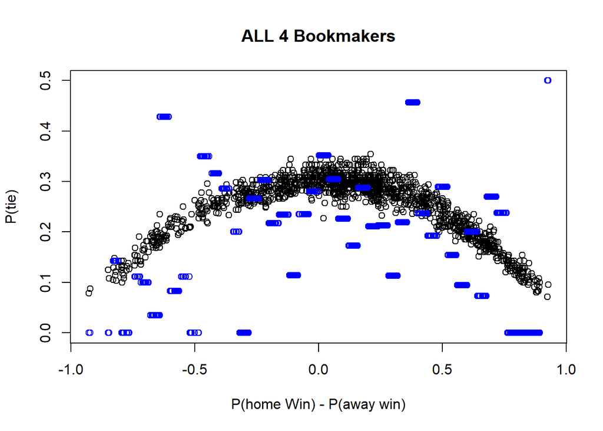

```r
plot(premierBets$Pdiff,premierBets$Podd_x,main = "ALL 4 Bookmakers", xlab= "P(home Win) - P(away win)", ylab = "P(tie)", ylim = c(0,0.5))
points(joinTable$Pdiff,joinTable$prob,col="blue")
```

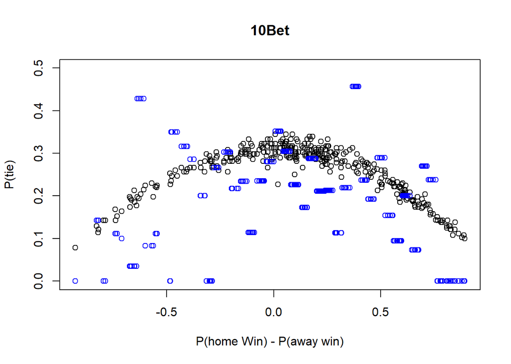

```r
plot(premierBets[odd_bookmakers == selectedBookmakers[1]]$Pdiff,premierBets[odd_bookmakers == selectedBookmakers[1]]$Podd_x,main = selectedBookmakers[1], xlab= "P(home Win) - P(away win)", ylab = "P(tie)", ylim = c(0,0.5))
points(joinTable[odd_bookmakers == selectedBookmakers[1]]$Pdiff,joinTable[odd_bookmakers == selectedBookmakers[1]]$prob,col="blue")
```

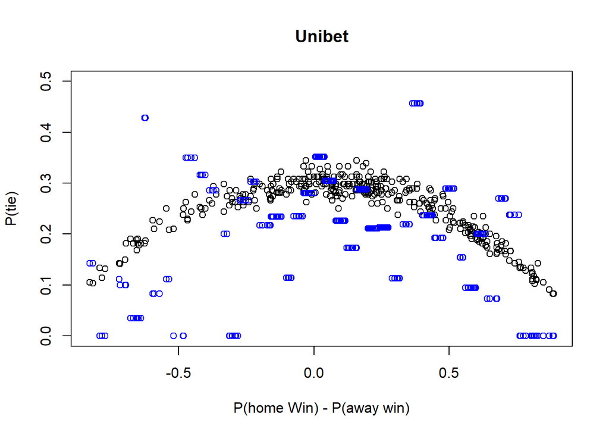

```r
plot(premierBets[odd_bookmakers == selectedBookmakers[2]]$Pdiff,premierBets[odd_bookmakers == selectedBookmakers[2]]$Podd_x,main = selectedBookmakers[2], xlab= "P(home Win) - P(away win)", ylab = "P(tie)", ylim = c(0,0.5))
points(joinTable[odd_bookmakers == selectedBookmakers[2]]$Pdiff,joinTable[odd_bookmakers == selectedBookmakers[2]]$prob,col="blue")
```

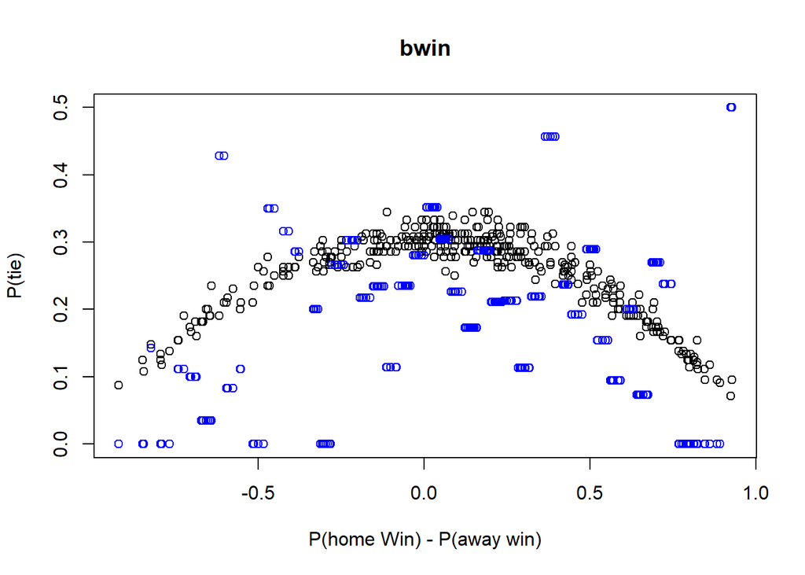

```r
plot(premierBets[odd_bookmakers == selectedBookmakers[3]]$Pdiff,premierBets[odd_bookmakers == selectedBookmakers[3]]$Podd_x,main = selectedBookmakers[3], xlab= "P(home Win) - P(away win)", ylab = "P(tie)", ylim = c(0,0.5))
points(joinTable[odd_bookmakers == selectedBookmakers[3]]$Pdiff,joinTable[odd_bookmakers == selectedBookmakers[3]]$prob,col="blue")
```

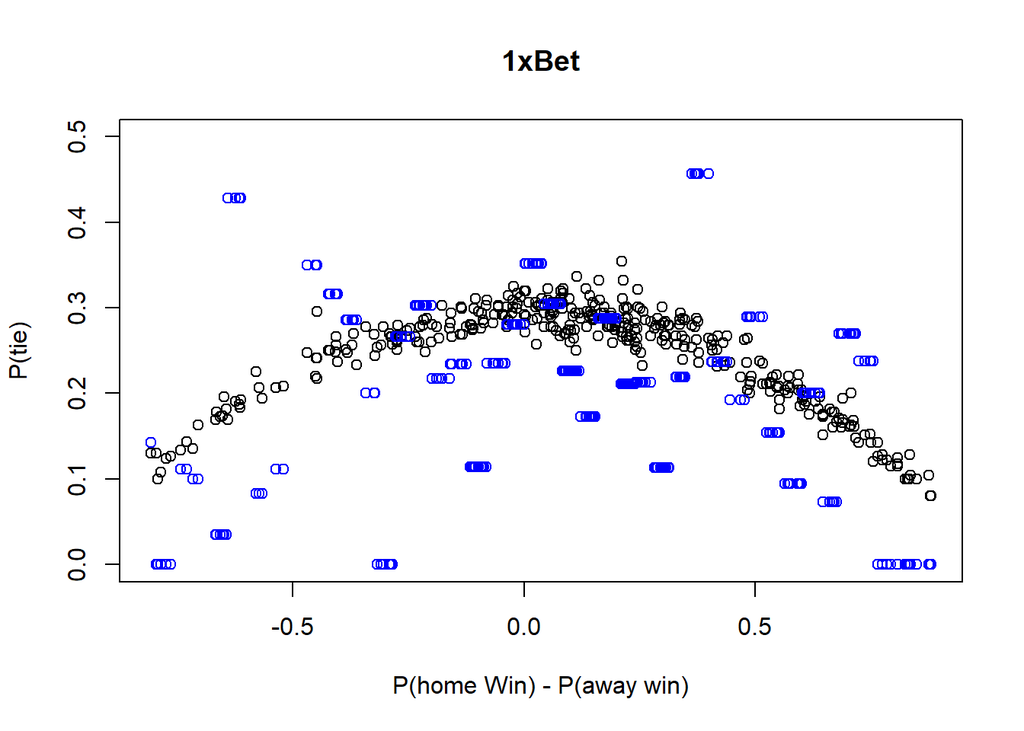

```r
plot(premierBets[odd_bookmakers == selectedBookmakers[4]]$Pdiff,premierBets[odd_bookmakers == selectedBookmakers[4]]$Podd_x,main = selectedBookmakers[4], xlab= "P(home Win) - P(away win)", ylab = "P(tie)", ylim = c(0,0.5))
points(joinTable[odd_bookmakers == selectedBookmakers[4]]$Pdiff,joinTable[odd_bookmakers == selectedBookmakers[4]]$prob,col="blue")
```

## TASK 3

For this part of the homework, I first found if there was a red card in the first 15 minutes of the games. It is called as “redBef15” in the booking data. Also using the matches data and extra time scores, I calculated the result of the game at 90th minute, called it as “result90”. “result90” is then compared with “result” calculated before, in order to be able to say if draw outcome is affected by extra minutes.

```r
DTbookingData[,"redBef15":=ifelse(as.numeric(time)<15&card == "red card" , 1 , 0)]
DTpremierMatches[,"result90" := ifelse(goal_1-match_hometeam_extra_score>goal_2-match_awayteam_extra_score,1,ifelse(goal_2-match_awayteam_extra_score>goal_1-match_hometeam_extra_score,2,0))]
```

As seen below, variable “extraChange” becomes 1 if draw outcome changed at the extra minutes or there is a draw outcome due to extra minutes.

```r
DTpremierMatches[,"extraChange" := (result == 0 & result90 != 0) | (result != 0 & result90 == 0)]

setkey(DTbookingData,match_id)
setkey(DTpremierMatches,match_id)
setkey(joinTable,match_id)
bookSub <- DTbookingData[redBef15 == 1,.(match_id,redBef15)]
joinTable <- bookSub[joinTable, on="match_id"]
matchesSub <- DTpremierMatches[extraChange==1,.(match_id,extraChange)]
joinTable <- matchesSub[joinTable, on="match_id"]
```

These actions will remove some matches as shown below:

```r
joinTable[extraChange==1,.N]
```

```
## [1] 446
```

```r
joinTable[redBef15==1,.N]
```

```
## [1] 8
```

```r
joinTable[redBef15==1|extraChange==1,.N]
```

```
## [1] 450
```

All graphs are drawn again after the joinTable is reduced. I do not see a significant difference in the visuals, although there is some variance removed, it looks like.

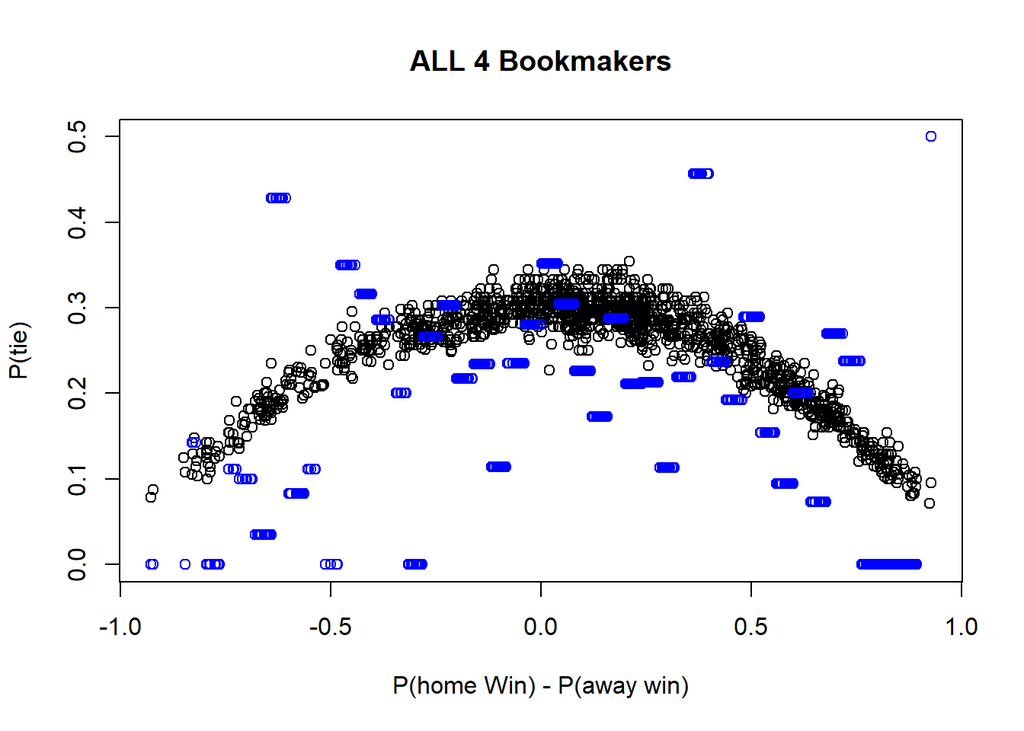

```r
joinTable<-joinTable[is.na(extraChange) & is.na(redBef15)]

plot(premierBets$Pdiff,premierBets$Podd_x,main = "ALL 4 Bookmakers", xlab= "P(home Win) - P(away win)", ylab = "P(tie)", ylim = c(0,0.5))
points(joinTable$Pdiff,joinTable$prob,col="blue")
```

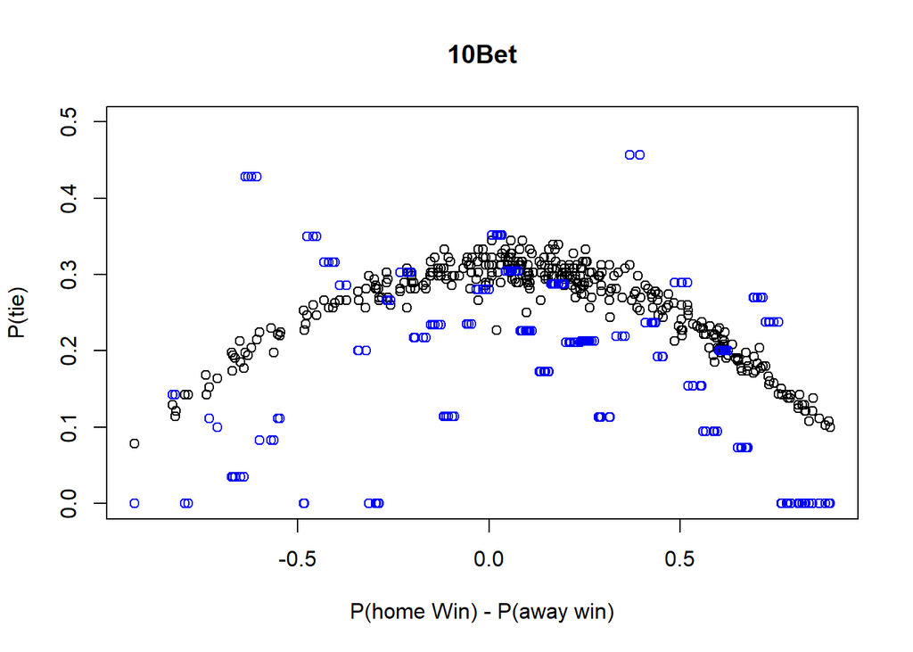

```r
plot(premierBets[odd_bookmakers == selectedBookmakers[1]]$Pdiff,premierBets[odd_bookmakers == selectedBookmakers[1]]$Podd_x,main = selectedBookmakers[1], xlab= "P(home Win) - P(away win)", ylab = "P(tie)", ylim = c(0,0.5))
points(joinTable[odd_bookmakers == selectedBookmakers[1]]$Pdiff,joinTable[odd_bookmakers == selectedBookmakers[1]]$prob,col="blue")
```

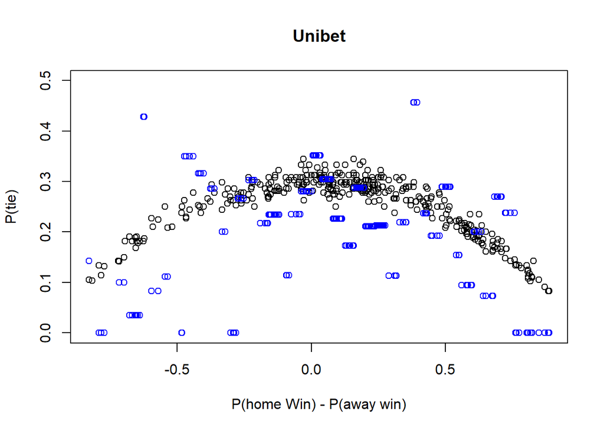

```r
plot(premierBets[odd_bookmakers == selectedBookmakers[2]]$Pdiff,premierBets[odd_bookmakers == selectedBookmakers[2]]$Podd_x,main = selectedBookmakers[2], xlab= "P(home Win) - P(away win)", ylab = "P(tie)", ylim = c(0,0.5))
points(joinTable[odd_bookmakers == selectedBookmakers[2]]$Pdiff,joinTable[odd_bookmakers == selectedBookmakers[2]]$prob,col="blue")
```

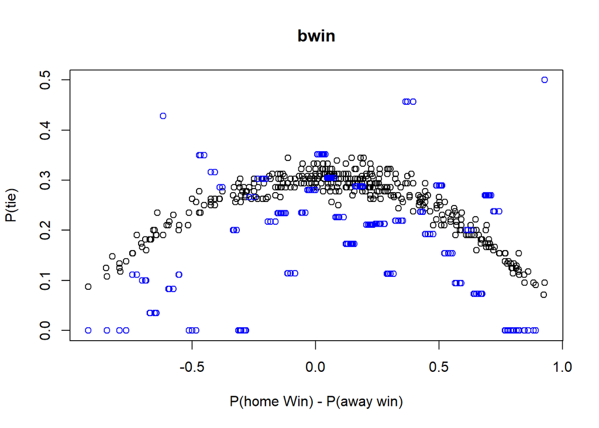

```r
plot(premierBets[odd_bookmakers == selectedBookmakers[3]]$Pdiff,premierBets[odd_bookmakers == selectedBookmakers[3]]$Podd_x,main = selectedBookmakers[3], xlab= "P(home Win) - P(away win)", ylab = "P(tie)", ylim = c(0,0.5))
points(joinTable[odd_bookmakers == selectedBookmakers[3]]$Pdiff,joinTable[odd_bookmakers == selectedBookmakers[3]]$prob,col="blue")
```

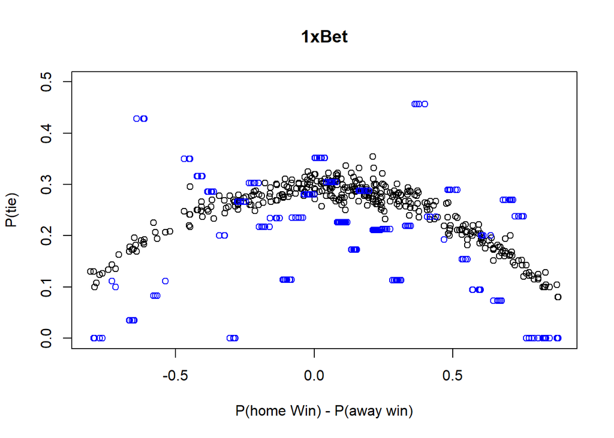

```r
plot(premierBets[odd_bookmakers == selectedBookmakers[4]]$Pdiff,premierBets[odd_bookmakers == selectedBookmakers[4]]$Podd_x,main = selectedBookmakers[4], xlab= "P(home Win) - P(away win)", ylab = "P(tie)", ylim = c(0,0.5))
points(joinTable[odd_bookmakers == selectedBookmakers[4]]$Pdiff,joinTable[odd_bookmakers == selectedBookmakers[4]]$prob,col="blue")
```